# Bayesian modeling and prediction for movies

## Setup

### Load packages

```r
library(devtools)
```

```r
install_github("StatsWithR/statsr")
library(ggplot2)
library(dplyr)
library(statsr)
library(BAS)
```

### Load data

```r
load("movies.Rdata")
```

## Part 1: Data

The data is obtained randomly sampling from two databases of movie ratings. As such, analysis on this data can be generalized to the whole population (the totality of the databases), but no causal relation can be infered.

## Part 2: Data manipulation

The next R script creates the new variables `feature_film`, `drama`, `mpaa_rating_R`, `oscar_season` and `summer_season`.

```r
movies <- movies %>%
  mutate(feature_film = ifelse(title_type == "Feature Film", "yes", "no")) %>%
  mutate(drama = ifelse(genre == "Drama", "yes", "no")) %>%
  mutate(mpaa_rating_R = ifelse(mpaa_rating == "R", "yes", "no" )) %>%
  mutate(oscar_season = ifelse( (thtr_rel_month >= 10) & (thtr_rel_month <= 12),
                                "yes", "no")) %>%

  mutate(summer_season = ifelse( (thtr_rel_month >= 5) & (thtr_rel_month <= 8),
                                "yes", "no"))
```

## Part 3: Exploratory data analysis

We will use the following function to make qq plots with the line showed

```r
qqplot.data <- function (vec) # argument: vector of numbers
{
  # following four lines from base R's qqline()
  y <- quantile(vec[!is.na(vec)], c(0.25, 0.75))
  x <- qnorm(c(0.25, 0.75))
  slope <- diff(y)/diff(x)
  int <- y[1L] - slope * x[1L]

  d <- data.frame(resids = vec)

  ggplot(d, aes(sample = resids)) + stat_qq() + geom_abline(slope = slope, intercept = int)
}
```

First lets have a look at the distribution of `audience_score`

```r
summary(movies$audience_score)
```

```
##    Min. 1st Qu.  Median    Mean 3rd Qu.    Max.
##   11.00   46.00   65.00   62.36   80.00   97.00
```

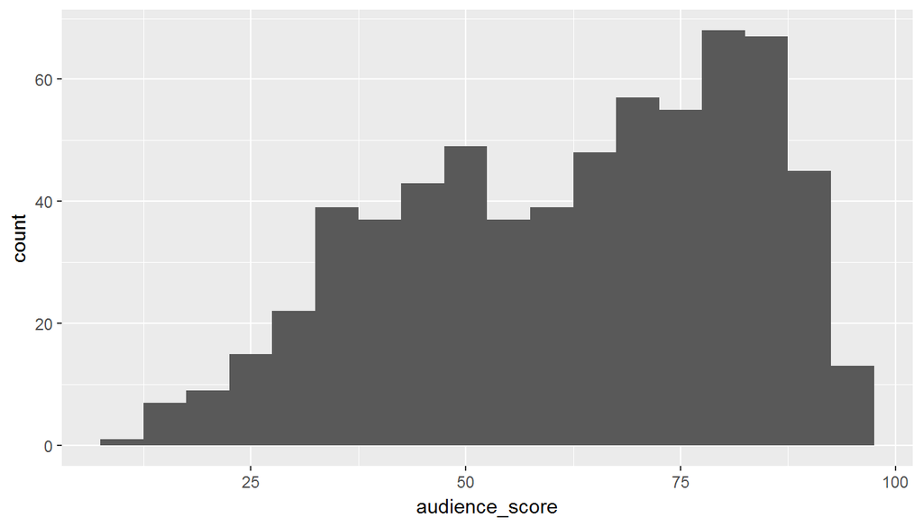

```r
movies %>%
  ggplot(aes(x = audience_score)) +
  geom_histogram(binwidth = 5)
```

It is left skewed and unimodal. Lets make it a bit more normal!

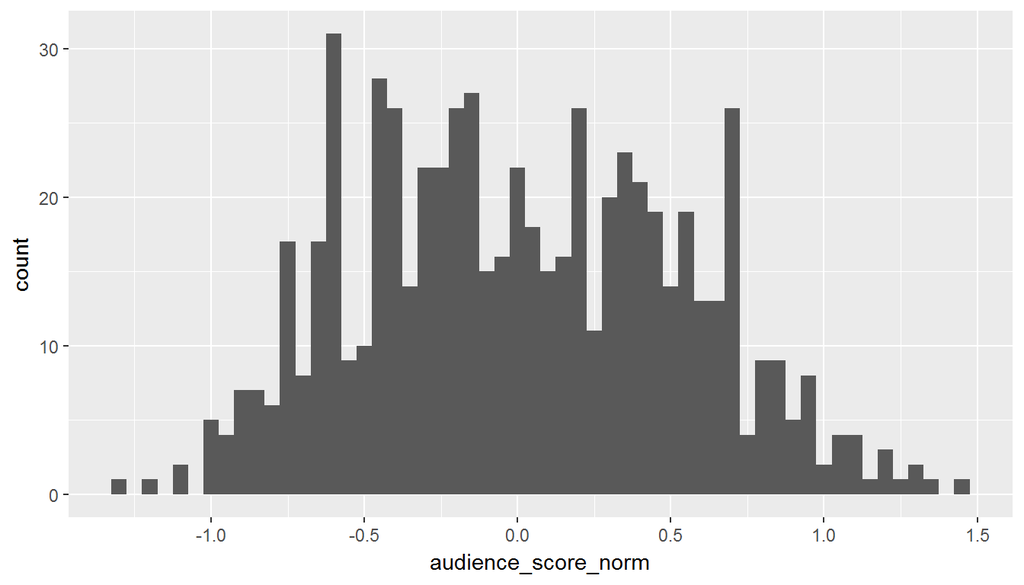

```r
movies <- movies %>%
  mutate(audience_score_norm = qnorm((1 - audience_score/100 )^(2/3)))
  #mutate(audience_score_norm = qnorm((1 - audience_score/100 )))
movies %>%
  ggplot(aes(x = audience_score_norm)) +
  geom_histogram(binwidth = 0.05)
```

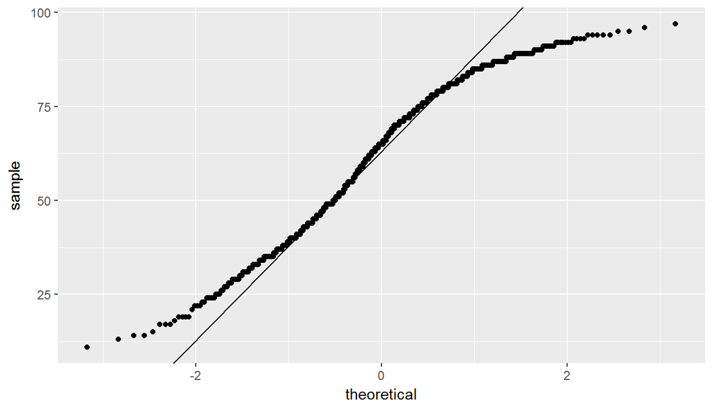

```r
qqplot.data(movies$audience_score)
```

This is a normal probability plot for `audience_score`. Now we check the plot for our handmade varable `audience_score_norm`

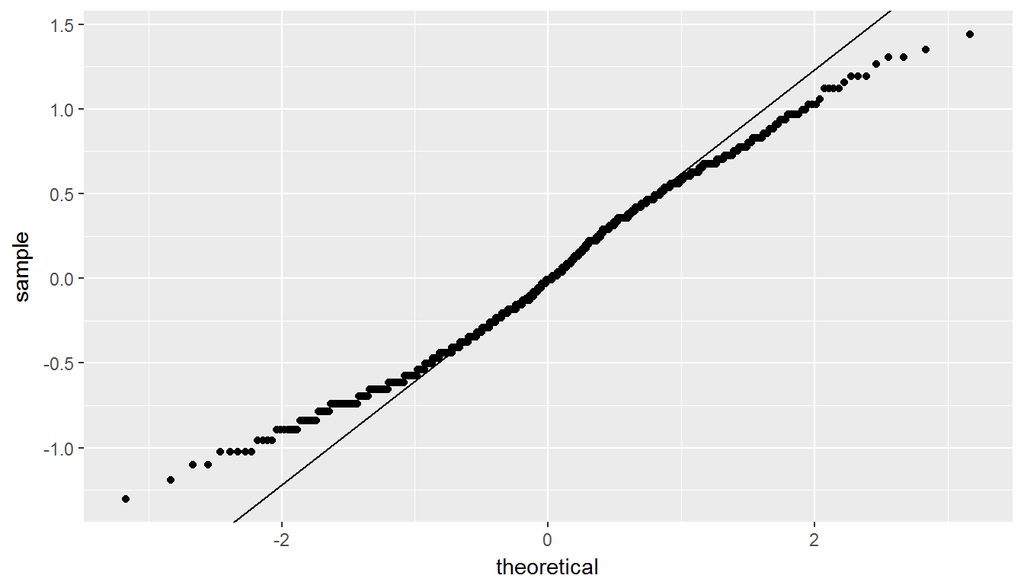

```r
qqplot.data(movies$audience_score_norm)
```

Far from a perfectly normal but way better then the original!

*REMARK* The variable `audience_score_norm` is reversed compared to `audience_score`. So a smaller value of `audience_score_norm` corresponds to an higher value of `audience_score`.

We can now move to explore the new variables we created above.

One of the simplest and most indicative plots possible for the 5 new varibles vs `audience_score`are boxplots. After each of them we table some summary statiscits of the score against the considered variable.

*drama*

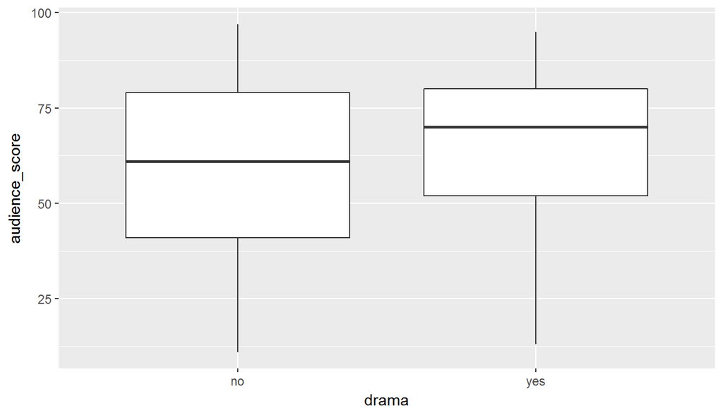

```r
movies %>%
  ggplot(aes(x = drama, y = audience_score)) +
  geom_boxplot()
```

```r
movies %>%
  group_by(drama) %>%
  summarise(avg = mean(audience_score), median = median(audience_score),
            std = sd(audience_score), IQR = IQR(audience_score), freq = n()/nrow(movies))
```

```
## # A tibble: 2 x 6
##   drama      avg median      std   IQR    freq
##   <chr>    <dbl>  <dbl>    <dbl> <dbl>   <dbl>
## 1    no 59.73121     61 21.27746    38 0.53149
## 2   yes 65.34754     70 18.54184    28 0.46851
```

Drama films are expected to be better recived by the audience (higher mean and median, lower IQR and std makes the mean and median more significant). Morevover, almost half of the sample (46.85%) are drama movies.

*Feature Films*

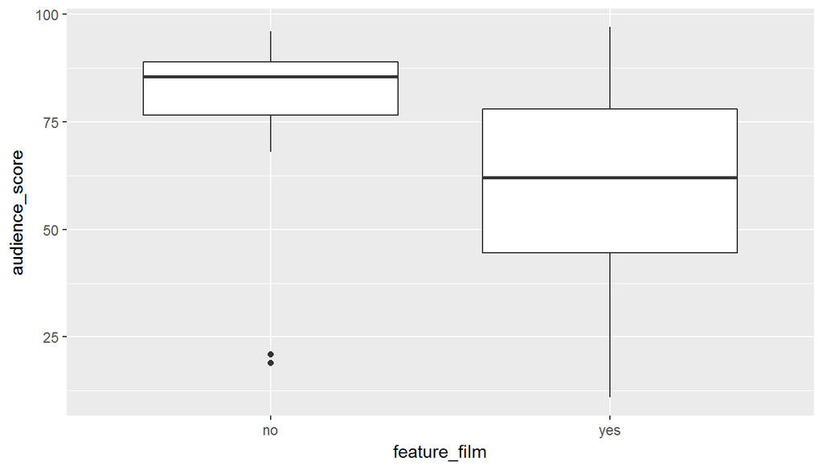

```r
movies %>%
  ggplot(aes(x = feature_film, y = audience_score)) +
  geom_boxplot()
```

```r
movies %>%
  group_by(feature_film) %>%
  summarise(avg = mean(audience_score), median = median(audience_score),
            std = sd(audience_score), IQR = IQR(audience_score), freq = n()/nrow(movies))
```

```
## # A tibble: 2 x 6
##   feature_film      avg median      std   IQR      freq
##          <chr>    <dbl>  <dbl>    <dbl> <dbl>     <dbl>
## 1           no 81.05000   85.5 13.57643  12.5 0.0921659
## 2          yes 60.46531   62.0 19.82402  33.5 0.9078341
```

Feature Films are expected to have lower audience score (significantly lower mean and median). However a vast majoritiy of movies (90.8%) are Feature Films.

*MPAA Rating R*

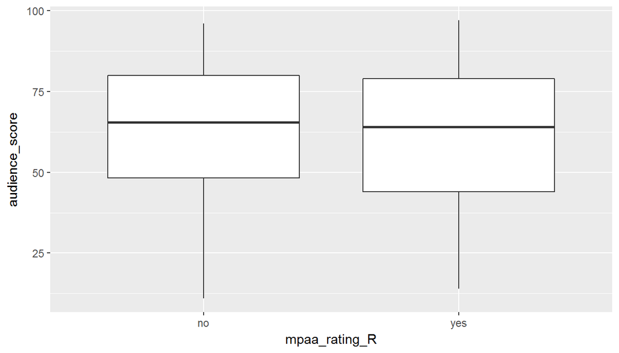

```r
movies %>%
  ggplot(aes(x = mpaa_rating_R, y = audience_score)) +
  geom_boxplot()
```

```r
movies %>%
  group_by(mpaa_rating_R) %>%
  summarise(avg = mean(audience_score), median = median(audience_score),
            std = sd(audience_score), IQR = IQR(audience_score), freq = n()/nrow(movies))
```

```
## # A tibble: 2 x 6
##   mpaa_rating_R      avg median      std   IQR      freq
##           <chr>    <dbl>  <dbl>    <dbl> <dbl>     <dbl>
## 1            no 62.68944   65.5 20.31672 31.75 0.4946237
## 2           yes 62.04255   64.0 20.15590 35.00 0.5053763
```

Both the plot and the summary statistics suggests that audience scores are indifferent of an MPAA rating R as opposed of another rating. Half of the movies in the sample are rated R.

*Oscar Season*

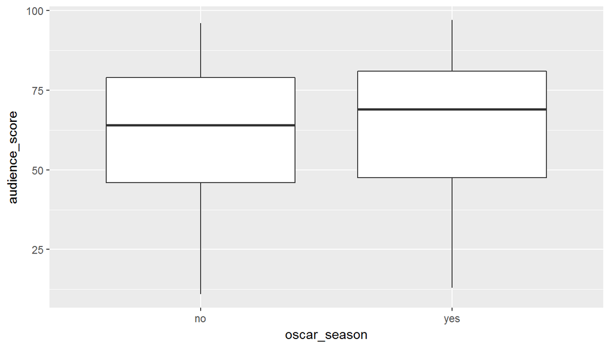

```r
movies %>%
  ggplot(aes(x = oscar_season, y = audience_score)) +
  geom_boxplot()
```

```r
movies %>%
  group_by(oscar_season) %>%
  summarise(avg = mean(audience_score), median = median(audience_score),
            std = sd(audience_score), IQR = IQR(audience_score), freq = n()/nrow(movies))
```

```
## # A tibble: 2 x 6
##   oscar_season      avg median      std   IQR      freq
##          <chr>    <dbl>  <dbl>    <dbl> <dbl>     <dbl>
## 1           no 61.81304     64 20.11957  33.0 0.7066052
## 2          yes 63.68586     69 20.46115  33.5 0.2933948
```

Both the plot and the summary statistics suggests that audience scores are indifferent from the movie being released in the Oscar season. 29.34% of the movies are released in Oscar Season.

*Summer Season*

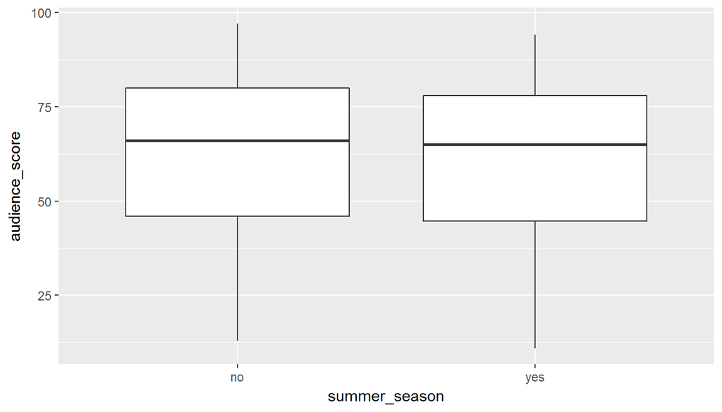

```r
movies %>%
  ggplot(aes(x = summer_season, y = audience_score)) +
  geom_boxplot()
```

```r
movies %>%
  group_by(summer_season) %>%
  summarise(avg = mean(audience_score), median = median(audience_score),
            std = sd(audience_score), IQR = IQR(audience_score), freq = n()/nrow(movies))
```

```
## # A tibble: 2 x 6
##   summer_season      avg median      std   IQR      freq
##           <chr>    <dbl>  <dbl>    <dbl> <dbl>     <dbl>
## 1            no 62.62302     66 20.38565 34.00 0.6804916
## 2           yes 61.80769     65 19.90828 33.25 0.3195084
```

Both the plot and the summary statistics suggests that audience scores are indifferent from the movie being released in thesummer season. 31.95% of the movies are released in summer.

## Part 4: Modeling

There are 16 variables in the full model. This means that there are a total of 2^16 = 65536 possible models.

We use BAS package to du Bayesian Aadapting Sampling, starting from the full model reqired.

```r
movies_nona = na.omit(movies)
bma_movies = bas.lm(audience_score_norm ~ feature_film +
                                     drama +
                                     runtime +
                                     mpaa_rating_R +
                                     thtr_rel_year +
                                     oscar_season +
                                     summer_season +
                                     imdb_rating +
                                     imdb_num_votes +
                                     critics_score +
                                     best_pic_nom +
                                     best_pic_win +
                                     best_actor_win +
                                     best_actress_win +
                                     best_dir_win +
                                     top200_box,
                   data = movies_nona,
                   prior = "BIC",
                   modelprior = uniform())
bma_movies
```

```
##
## Call:
## bas.lm(formula = audience_score_norm ~ feature_film + drama +     runtime + mpaa_rating_R + thtr_rel_year + oscar_season +     summer_season + imdb_rating + imdb_num_votes + critics_score +     best_pic_nom + best_pic_win + best_actor_win + best_actress_win +     best_dir_win + top200_box, data =…
##
##
##  Marginal Posterior Inclusion Probabilities:
##           Intercept      feature_filmyes             dramayes
##             1.00000              0.27070              0.04288
##             runtime     mpaa_rating_Ryes        thtr_rel_year
##             0.82088              0.13723              0.19408
##     oscar_seasonyes     summer_seasonyes          imdb_rating
##             0.05600              0.07305              1.00000
##      imdb_num_votes        critics_score      best_pic_nomyes
##             0.34301              0.78942              0.64359
##     best_pic_winyes    best_actor_winyes  best_actress_winyes
##             0.04535              0.08810              0.19909
##     best_dir_winyes        top200_boxyes
##             0.04520              0.04511
```

```r
summary(bma_movies)
```

```
##                     P(B != 0 | Y)    model 1       model 2       model 3
## Intercept              1.00000000     1.0000     1.0000000     1.0000000
## feature_filmyes        0.27069708     0.0000     0.0000000     0.0000000
## dramayes               0.04287852     0.0000     0.0000000     0.0000000
## runtime                0.82087921     1.0000     1.0000000     1.0000000
## mpaa_rating_Ryes       0.13723298     0.0000     0.0000000     0.0000000
## thtr_rel_year          0.19407778     0.0000     0.0000000     0.0000000
## oscar_seasonyes        0.05599971     0.0000     0.0000000     0.0000000
## summer_seasonyes       0.07304591     0.0000     0.0000000     0.0000000
## imdb_rating            1.00000000     1.0000     1.0000000     1.0000000
## imdb_num_votes         0.34301416     0.0000     0.0000000     1.0000000
## critics_score          0.78942083     1.0000     1.0000000     1.0000000
## best_pic_nomyes        0.64358533     1.0000     0.0000000     0.0000000
## best_pic_winyes        0.04534933     0.0000     0.0000000     0.0000000
## best_actor_winyes      0.08809812     0.0000     0.0000000     0.0000000
## best_actress_winyes    0.19909425     0.0000     0.0000000     0.0000000
## best_dir_winyes        0.04520429     0.0000     0.0000000     0.0000000
## top200_boxyes          0.04510649     0.0000     0.0000000     0.0000000
## BF                             NA     1.0000     0.3511869     0.3287508
## PostProbs                      NA     0.1047     0.0368000     0.0344000
## R2                             NA     0.7580     0.7547000     0.7572000
## dim                            NA     5.0000     4.0000000     5.0000000
## logmarg                        NA -1164.6526 -1165.6989908 -1165.7650094
##                         model 4      model 5
## Intercept               1.00000     1.000000
## feature_filmyes         0.00000     0.000000
## dramayes                0.00000     0.000000
## runtime                 1.00000     1.000000
## mpaa_rating_Ryes        0.00000     0.000000
## thtr_rel_year           0.00000     0.000000
## oscar_seasonyes         0.00000     0.000000
## summer_seasonyes        0.00000     0.000000
## imdb_rating             1.00000     1.000000
## imdb_num_votes          0.00000     0.000000
## critics_score           1.00000     0.000000
## best_pic_nomyes         1.00000     1.000000
## best_pic_winyes         0.00000     0.000000
## best_actor_winyes       0.00000     0.000000
## best_actress_winyes     1.00000     0.000000
## best_dir_winyes         0.00000     0.000000
## top200_boxyes           0.00000     0.000000
## BF                      0.27327     0.245255
## PostProbs               0.02860     0.025700
## R2                      0.75950     0.754400
## dim                     6.00000     4.000000
## logmarg             -1165.94985 -1166.058011
```

In order to do predictions, and so compute fitted values and residuals we extract the Best Predictive Model from the BAS. We prefere this over others (Highest Probability Model being a good other candidate) because it is the closest to the Bayesian Model Averaging, and so it shares the spirit of considering more than one model at a time (even if it is just one model, it is selected as the closest to the avarage of all of them).

```r
BPM_pred_movies =  predict(bma_movies, estimator="BPM", se.fit=TRUE)
```

Variables used by `BPM_pred_movies`

```r
bma_movies$namesx[BPM_pred_movies$bestmodel + 1]
```

```
## [1] "Intercept"       "dramayes"        "runtime"         "imdb_rating"
## [5] "critics_score"   "best_pic_nomyes"
```

*Model Interpretation*

Let’s extract the coefficients from the BPM, and plot their posterior probability distributions.

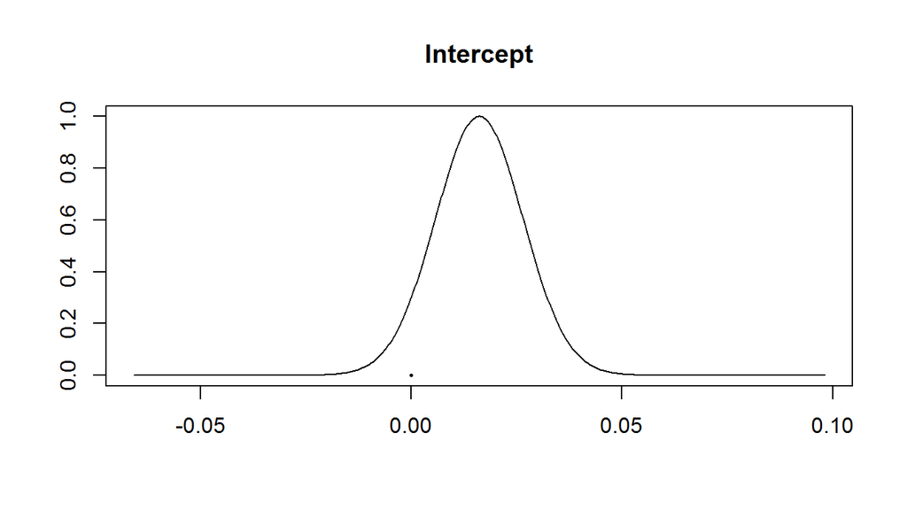

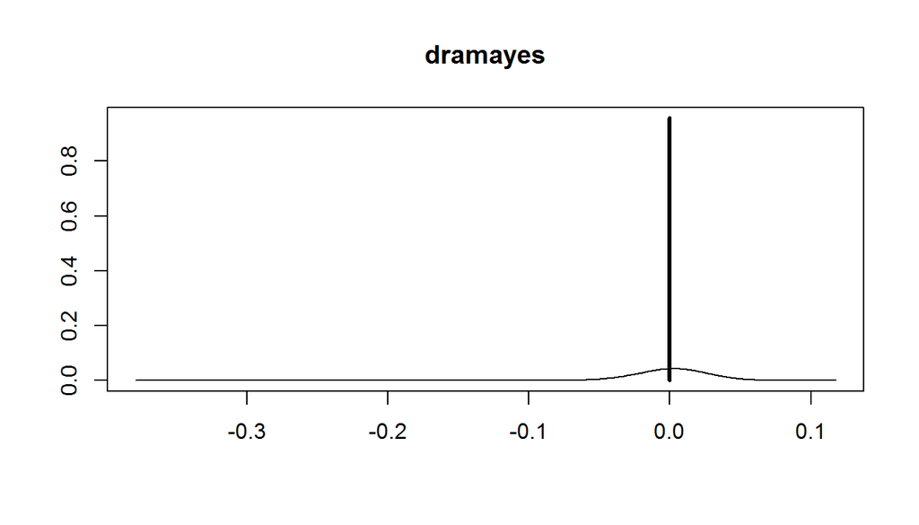

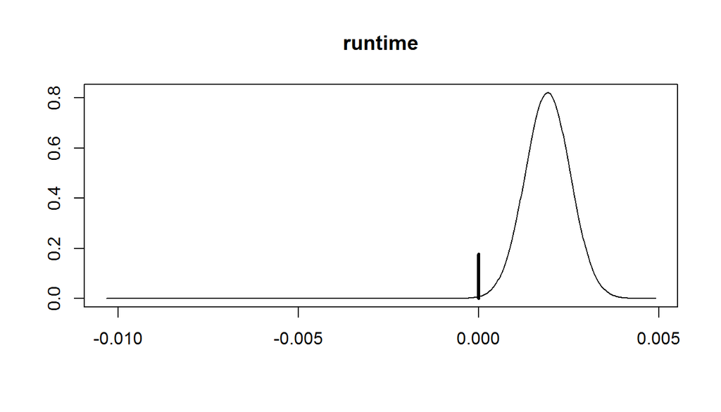

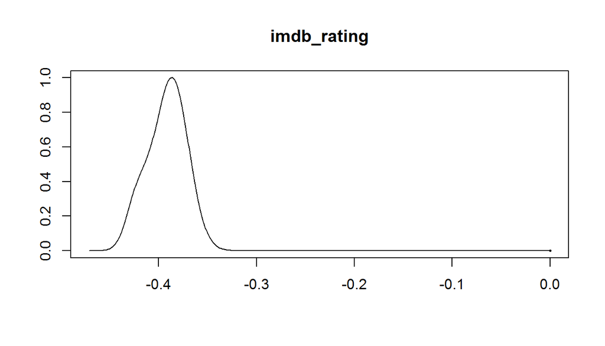

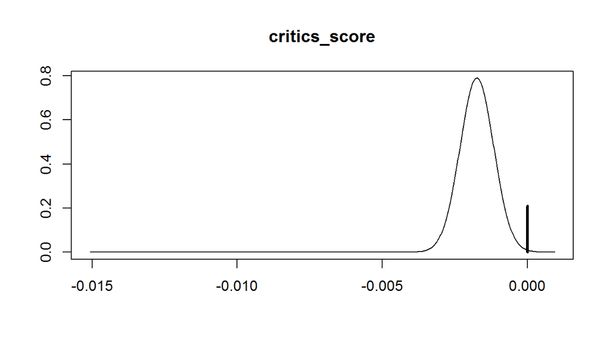

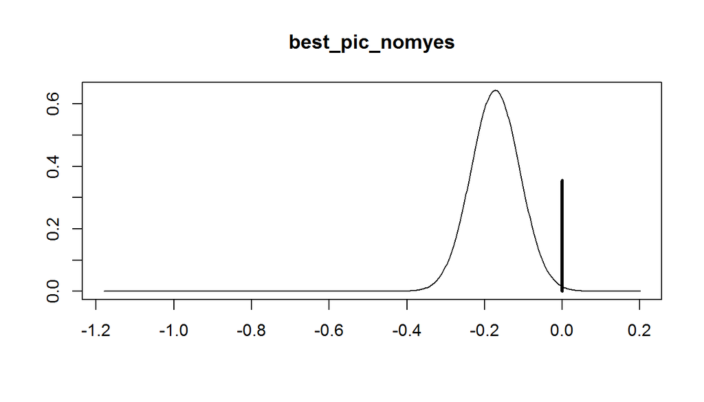

```r
movies_coeffs <- coef(bma_movies)

plot(movies_coeffs, subset = c(BPM_pred_movies$bestmodel + 1), ask = F)
```

We can also show 95% confidence intervals for the coefficients

```r
confint(movies_coeffs, parm = c(BPM_pred_movies$bestmodel + 1))
```

```
##                         2.5%        97.5%          beta
## Intercept       -0.004661862  0.036063052  1.611652e-02
## dramayes         0.000000000  0.000000000  6.752587e-05
## runtime          0.000000000  0.002906459  1.570521e-03
## imdb_rating     -0.433298334 -0.354518182 -3.921744e-01
## critics_score   -0.002643008  0.000000000 -1.377739e-03
## best_pic_nomyes -0.263557705  0.000000000 -1.106974e-01
## attr(,"Probability")
## [1] 0.95
## attr(,"class")
## [1] "confint.bas"
```

First recall that `audience_score_norm` is reversed compared to `audience_score`, so negative coefficients indicates POSITIVELY correlated variables to the `audience_score`. From the output above and the plots of the posterior distribution of the coefficients, appears surprising the inclusion of `drama` in the BPM, as its coefficient is predicted to be 0 with high probability. The two most probable parameters are `imdb_rating` and `runtime`. The first is predicted far from 0 (in the interval -0.43, -0.35) with 95% confidence, so we expect it to be the most relevant for prediction, and positively correlated to `audience_score`. The second, `runtime` has an high probability to be non zero, however 0 is its lower bound in a 95% confidence interval. Moreover it is predicted to be positive, i.e. negatively correlated with the `audience_score`.

*Model Dignostic*

Compute the residuals first

```r
movies_nona <- movies_nona %>%
  mutate(BPM_fitted = BPM_pred_movies$fit, BPM_resid = audience_score_norm - BPM_fitted)
```

We plot the absolute values of the residuals vs the fitted values:

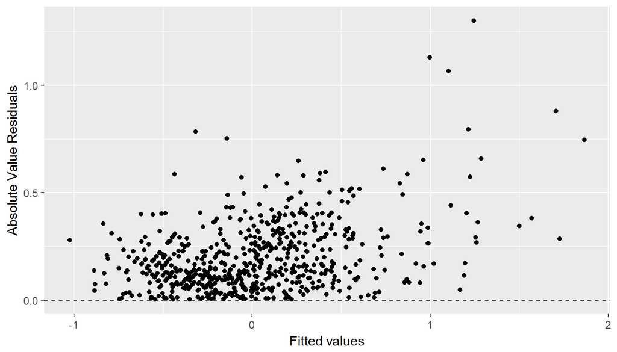

```r
movies_nona %>%
ggplot(aes(x = BPM_fitted, y = abs(BPM_resid))) +
  geom_point() +
  geom_hline(yintercept = 0, linetype = "dashed") +
  xlab("Fitted values") +
  ylab("Absolute Value Residuals")
```

The use of `audience_score_norm`has been helpful here, however there is still some variability on the plot and the assumption of constant variability of the residual is essentially violated.

Now we check the distribution of the residuals

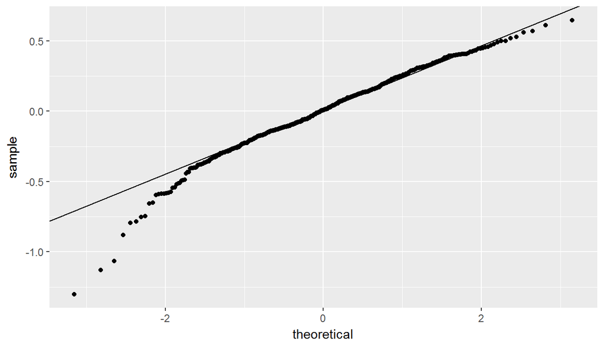

```r
qqplot.data(movies_nona$BPM_resid)
```

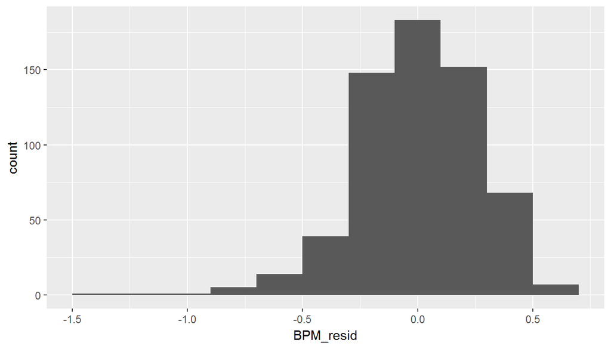

```r
ggplot(data = movies_nona, aes(x = BPM_resid)) + geom_histogram(binwidth = 0.2)
```

Residuals are slightly left skewed.

Finally we check the linearity assumption with respect to the variables selected by BPM. We do so plotting the residuals against the variables.

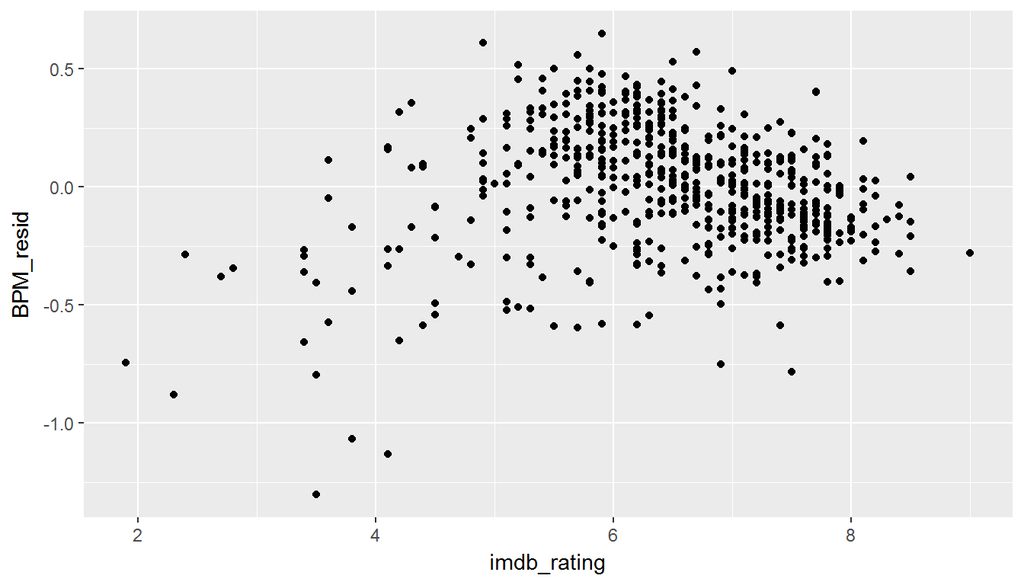

```r
movies_nona %>%
  ggplot(aes(x = imdb_rating, y = BPM_resid))+
  geom_point()
```

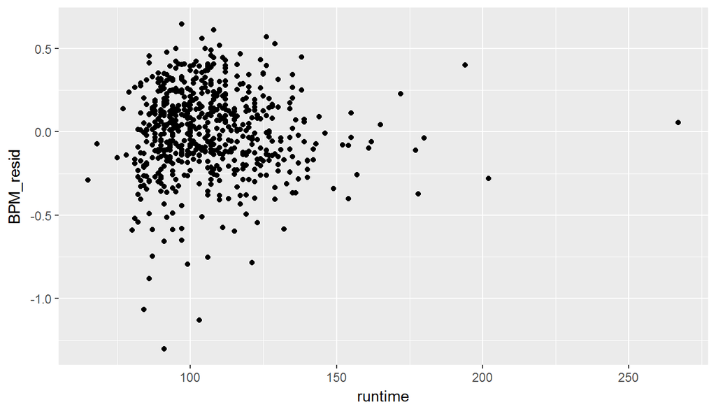

```r
movies_nona %>%
  ggplot(aes(x = runtime, y = BPM_resid))+
  geom_point()
```

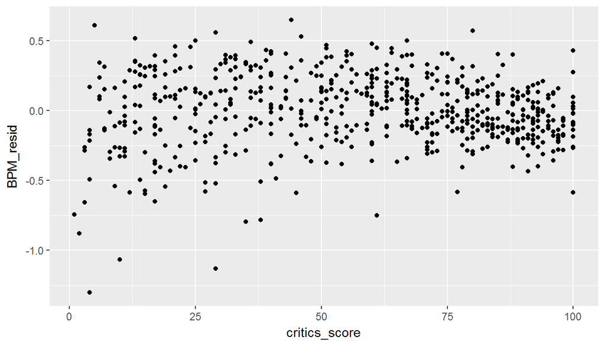

```r
movies_nona %>%
  ggplot(aes(x = critics_score, y = BPM_resid))+
  geom_point()
```

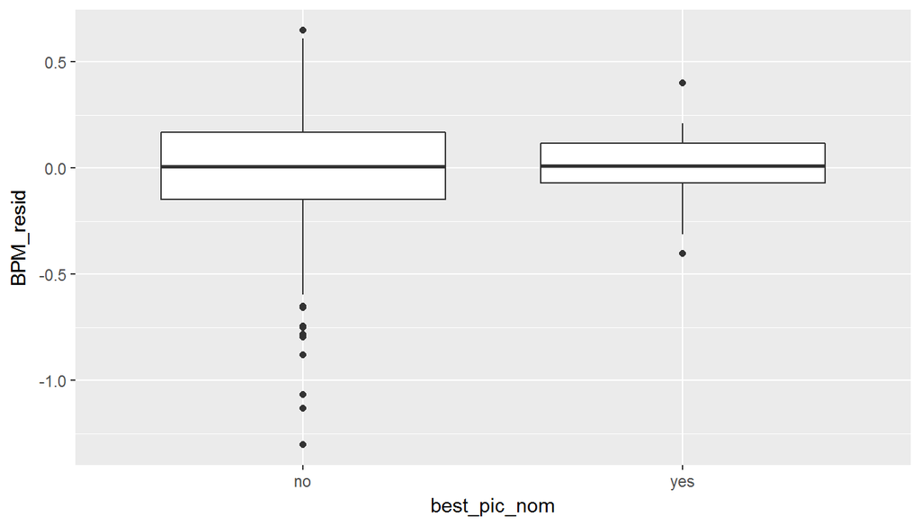

```r
movies_nona %>%
  ggplot(aes(x = best_pic_nom, y = BPM_resid)) +
  geom_boxplot()
```

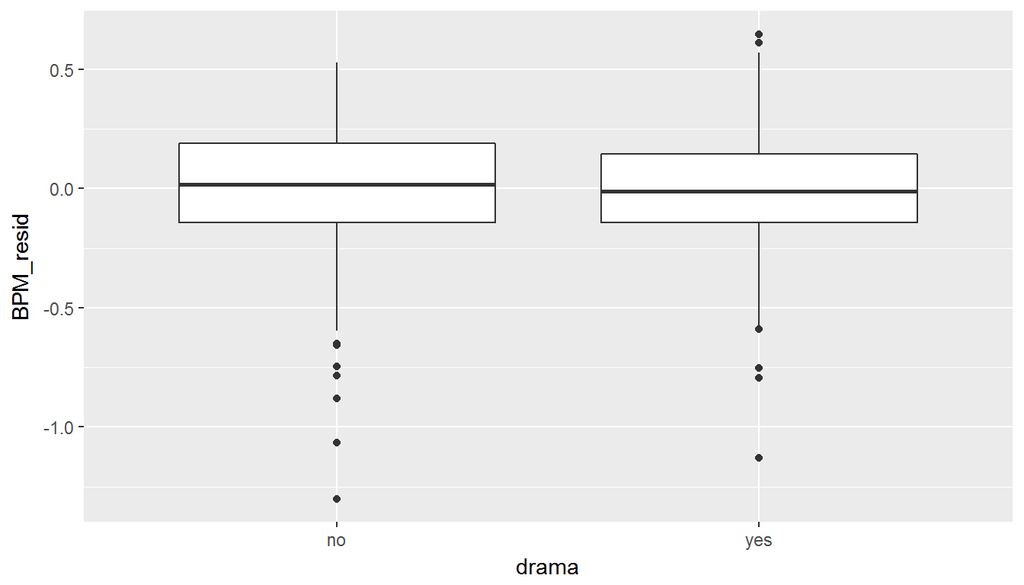

```r
movies_nona %>%
  ggplot(aes(x = drama, y = BPM_resid)) +
  geom_boxplot()
```

There is clearly a problem in the distribution of the residuals with respect to `runtime` and `imdb_rating`. Also the distribution versus `best_pic_nom` is not optimal. This suggest that the relation between `audience_score_norm` and these variables may be non linear.

## Part 5: Prediction

For the prediction we use Batman v Superman: Dawn of Justice. It was a commercial success but generally considered a bad film, it has critics score 27, an audience score 63 and an imdb rating of 6.6. Data were taken from the websites of IMDB, Rotten Tomatoes and BoxOfficeMojo.

```r
BvS <- data.frame(title = "Batman V Superman: dawn of Justice",
                  feature_film = "yes",
                  mpaa_rating_R = "no",
                  oscar_season = "no",
                  summer_season = "no",
                  title_type = "Feature Film",
                  genre = "Action & Adventure",
                  drama = "no",
                  runtime = 151,
                  mpaa_rating = "PG-13",
                  thtr_rel_year = 2016,
                  best_pic_nom = "no",
                  best_pic_win = "no",
                  best_dir_win = "no",
                  best_actor_win = "no",
                  best_actress_win = "no",
                  imdb_rating = 6.6,
                  imdb_num_votes = 496633,
                  critics_score = 27,
                  top200_box = "yes")

BvS_predict = predict(bma_movies, newdata = BvS, estimator = "BPM",se.fit = TRUE)
```

We can now compute the explicit prediction for the `audience_score` and its 95% confindence interval. Recall that we have to do some work to go from `audience_score_norm` to `audience_score`

```r
y = confint(BvS_predict)
(1 - pnorm(y)^(3/2))*100
```

```
##          2.5%    97.5%     pred
## [1,] 82.18364 39.03351 62.45047
## attr(,"Probability")
## [1] 0.95
## attr(,"class")
## [1] "confint.bas"
```

The resulting prediction of 62.45 is pretty near to the true value of 63. The confidence interval is however a bit large (39, 82.18)

## Part 6: Conclusion

This exercises shows that, under a bayesian approach, model selection reduces the number of parameters by a lot, and only keeps few very important variables (important in terms of posterior probability). This is very interesting compared to other model selection tachniques I used in this dataset in previous exercises, where many more varibles where kept.

Even if we have only few variables the prediction with the Best Predictive Model gives a good fitted value, however the confidence interval is large, suggesting low precision. This is what one should expect from a Bayesian approach and more data may improve this.

A remark could be that the score on IMDB is the best predictor for the audience score and is stronger than the critics score from Rotten Tomatoes. This suggests that the rating on imdb is more related to the popularity (audience_score) then critics reviews.

Finally let me remrk again that a lot of linearity assumptions are violated by this model so it would be a good idea to try some non linear regression technique on the same dataset.